# Using Limma for Microarray Data Analysis

Mariona Alberola

29 de mayo de 2019

## Summary

UHRF1 is a major regulator of epigenetic mechanism and is overexpressed in various human malignancies. In this study, we examined the involvement of UHRF1 in aberrant DNA methylation in colorectal cancer (CRC). In CRC cells, transient UHRF1 knockdown rapidly induced DNA demethylation across entire genomic regions, including CpG islands, gene bodies and repetitive elements. Nonetheless, UHRF1 depletion only minimally reversed CpG island hypermethylation-associated gene silencing. However, the combination of UHRF1 depletion and histone deacetylase (HDAC) inhibition synergistically reactivated the silenced genes and strongly suppressed CRC cell proliferation. Our results suggest that (i) maintenance of DNA methylation in CRC cells is highly dependent on UHRF1; (ii) UHRF1 depletion rapidly induces DNA demethylation, though it is insufficient to fully reactivate the silenced genes; and (iii) dual targeting of UHRF1 and HDAC may be an effective new therapeutic strategy.

Obviously this is an observational study but its analysis can be done using a linear model approach as well.

1. Identify the experimental factors and their levels.
2. Write down the design matrix associated with this study design.
3. Build the contrast matrix that is:
   1. “siCONT_noTSA” vs “siUHRF1_noTSA”
   2. “siCONT_noTSA” vs “siCONT_TSA”
   3. “siCONT_noTSA” vs “siUHRF1_TSA”
   4. “siUHRF1_noTSA” vs “siCONT_TSA”
   5. “siUHRF1_noTSA” vs “siUHRF1_TSA”
   6. “siCONT_TSA” vs “siUHRF1_TSA”

## Overall design

DLD1 cells were transfected with a control siRNA (Thermo Fisher Scientific) or siRNAs targeting UHRF1 (Thermo Fisher Scientific) using using Lipofectamine RNAiMAX (Thermo Fisher Scientific) and incubated for 48 h. Cells were then treated with mock (ethanol) or 300 nM Trichostatin A (TSA) for additional 24 h.

## Contributor(s)

Suzuki H

## Citation(s)

Niinuma T, Kitajima H, Kai M, Yamamoto E et al. UHRF1 depletion and HDAC inhibition reactivate epigenetically silenced genes in colorectal cancer cells. Clin Epigenetics 2019 May 7;11(1):70. PMID: 31064417

```r
targets<- read.csv("samples2.txt", sep="")
targets
```

```
##   Sample_Name Cell Experiment_Types Replicate
## 1  GSM2837219 DLD1     siCONT_noTSA         1
## 2  GSM2837220 DLD1     siCONT_noTSA         2
## 3  GSM2837221 DLD1    siUHRF1_noTSA         1
## 4  GSM2837222 DLD1    siUHRF1_noTSA         2
## 5  GSM2837223 DLD1       siCONT_TSA         1
## 6  GSM2837224 DLD1       siCONT_TSA         2
## 7  GSM2837225 DLD1      siUHRF1_TSA         1
## 8  GSM2837226 DLD1      siUHRF1_TSA         2
```

```r
expressions <- read.delim("GSE106402_series_matrix.txt", header = TRUE, row.names = 1)
dataMatrix <- expressions
```

```r
require(limma)

design <-model.matrix(~ 0+targets$Experiment_Types)
design
```

```
##   targets$Experiment_TypessiCONT_noTSA targets$Experiment_TypessiCONT_TSA
## 1                                    1                                  0
## 2                                    1                                  0
## 3                                    0                                  0
## 4                                    0                                  0
## 5                                    0                                  1
## 6                                    0                                  1
## 7                                    0                                  0
## 8                                    0                                  0
##   targets$Experiment_TypessiUHRF1_noTSA
## 1                                     0
## 2                                     0
## 3                                     1
## 4                                     1
## 5                                     0
```

[output cut: 17 more lines]

```r
colnames(design)<-c("cn", "un", "cs", "us")
rownames(design)<- targets$SampleIDs
 print(design)
```

```
##      cn un cs us
## [1,]  1  0  0  0
## [2,]  1  0  0  0
## [3,]  0  0  1  0
## [4,]  0  0  1  0
## [5,]  0  1  0  0
## [6,]  0  1  0  0
## [7,]  0  0  0  1
## [8,]  0  0  0  1
## attr(,"assign")
## [1] 1 1 1 1
## attr(,"contrasts")
## attr(,"contrasts")$`targets$Experiment_Types`
## [1] "contr.treatment"
```

```r
cont.matrix <- makeContrasts (
  cnVSun = cn-un,
  cnVScs = cn-cs,
  cnVSus = cn-us,
  unVScs = un-cs,
  unVSus = un-us,
  csVSus = cs-us,

  levels=design)
cont.matrix
```

```
##       Contrasts
## Levels cnVSun cnVScs cnVSus unVScs unVSus csVSus
##     cn      1      1      1      0      0      0
##     un     -1      0      0      1      1      0
##     cs      0     -1      0     -1      0      1
##     us      0      0     -1      0     -1     -1
```

```r
require(limma)
fit<-lmFit(dataMatrix, design)
fit.main<-contrasts.fit(fit, cont.matrix)
fit.main<-eBayes(fit.main)
```

```r
topTab_cnVSun <- topTable (fit.main, number=nrow(fit.main), coef="cnVSun", adjust="fdr"); head(topTab_cnVSun)
```

```
##           logFC   AveExpr          t      P.Value    adj.P.Val        B
## 58758  -414.880  160.4013 -141.71088 3.258385e-09 0.0001349259 2.076086
## 46673   -38.095   21.0975 -133.14794 4.284996e-09 0.0001349259 2.074532
## 20227  -353.500  401.8750 -115.99912 7.853587e-09 0.0001648625 2.070327
## 2745  -1804.500 1318.2500  -91.39561 2.238389e-08 0.0002474687 2.059701
## 8700   -178.500  130.5500  -91.03683 2.277405e-08 0.0002474687 2.059480
## 14545 -1659.000 1277.1250  -90.32124 2.357743e-08 0.0002474687 2.059032
```

```r
topTab_cnVScs <- topTable (fit.main, number=nrow(fit.main), coef="cnVScs", adjust="fdr"); head(topTab_cnVScs)
```

```
##         logFC  AveExpr         t      P.Value   adj.P.Val        B
## 20227  -245.0  401.875 -80.39543 3.931839e-08 0.002476115 2.051539
## 17204 -2215.0 3000.000 -56.73008 1.817818e-07 0.005723946 2.015490
## 33149  -218.5  334.375 -49.16270 3.407747e-07 0.007153543 1.991972
## 56780  -347.5  984.625 -42.00401 6.796945e-07 0.008363804 1.957448
## 27880 -1923.0 1346.500 -41.01766 7.543514e-07 0.008363804 1.951276
## 42495  -191.5  466.000 -39.12067 9.284321e-07 0.008363804 1.938120
```

```r
topTab_cnVSus <- topTable (fit.main, number=nrow(fit.main), coef="cnVSus", adjust="fdr"); head(topTab_cnVSus)
```

```
##          logFC   AveExpr          t      P.Value    adj.P.Val        B
## 44337 -5509.50 1783.7500 -213.70278 5.357644e-10 1.855219e-05 2.082655
## 7051   -778.18  197.8613 -209.13084 5.891829e-10 1.855219e-05 2.082427
## 30353  -169.53   56.2925 -136.32609 3.863076e-09 8.109369e-05 2.075143
## 8700   -226.50  130.5500 -115.51732 7.998538e-09 1.259290e-04 2.070181
## 39028   -32.78   13.2825 -104.81434 1.226155e-08 1.444429e-04 2.066411
## 20227  -301.00  401.8750  -98.77153 1.591664e-08 1.444429e-04 2.063724
```

```r
topTab_unVScs <- topTable (fit.main, number=nrow(fit.main), coef="unVScs", adjust="fdr"); head(topTab_unVScs)
```

```
##          logFC   AveExpr         t      P.Value    adj.P.Val        B
## 46673   44.815   21.0975 156.63538 2.098473e-09 0.0001040967 2.078212
## 58758  413.515  160.4013 141.24463 3.305915e-09 0.0001040967 2.076009
## 2745  1792.500 1318.2500  90.78782 2.304973e-08 0.0003105698 2.059325
## 14545 1657.500 1277.1250  90.23958 2.367131e-08 0.0003105698 2.058980
## 8700   175.300  130.5500  89.40479 2.465779e-08 0.0003105698 2.058442
## 26326 1741.500 1289.1250  75.59106 5.153977e-08 0.0003342534 2.046820
```

```r
topTab_unVSus <- topTable (fit.main, number=nrow(fit.main), coef="unVSus", adjust="fdr"); head(topTab_unVSus)
```

```
##           logFC    AveExpr          t      P.Value    adj.P.Val        B
## 7051   -778.360  197.86125 -209.17921 5.885844e-10 3.227129e-05 2.082429
## 44337 -4753.500 1783.75000 -184.37901 1.024876e-09 3.227129e-05 2.080883
## 30353  -130.250   56.29250 -104.73942 1.230014e-08 2.582045e-04 2.066381
## 39028   -27.080   13.28250  -86.58854 2.838046e-08 3.487829e-04 2.056512
## 44295   -34.715   13.61125  -84.95826 3.085192e-08 3.487829e-04 2.055307
## 46673    23.900   21.09750   83.53421 3.323008e-08 3.487829e-04 2.054196
```

```r
topTab_csVSus <- topTable (fit.main, number=nrow(fit.main), coef="csVSus", adjust="fdr"); head(topTab_csVSus)
```

```
##           logFC   AveExpr         t      P.Value    adj.P.Val        B
## 7051   -778.015  197.8613 -209.0865 5.897323e-10 1.900699e-05 2.082424
## 44337 -5362.000 1783.7500 -207.9815 6.036263e-10 1.900699e-05 2.082367
## 30353  -169.050   56.2925 -135.9401 3.911509e-09 8.211039e-05 2.075071
## 8700   -223.300  130.5500 -113.8853 8.514571e-09 1.143475e-04 2.069674
## 23328  -594.500  525.7500 -112.2347 9.078659e-09 1.143475e-04 2.069138
## 39028   -32.610   13.2825 -104.2708 1.254490e-08 1.316712e-04 2.066188
```

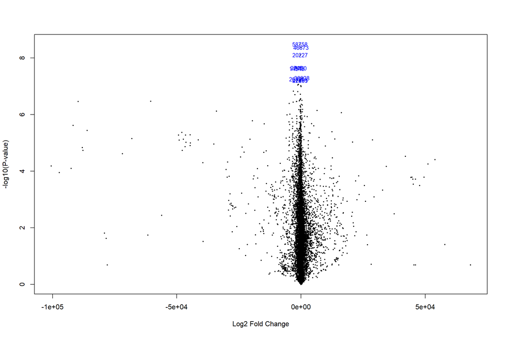

```r
volcanoplot(fit.main, coef="cnVSun", highlight=10)
```

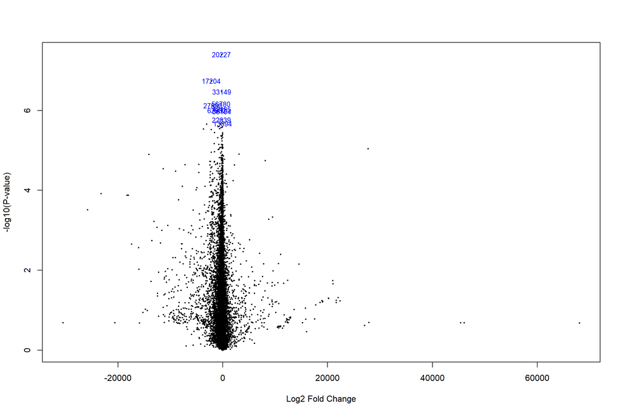

```r
volcanoplot(fit.main, coef="cnVScs", highlight=10)
```

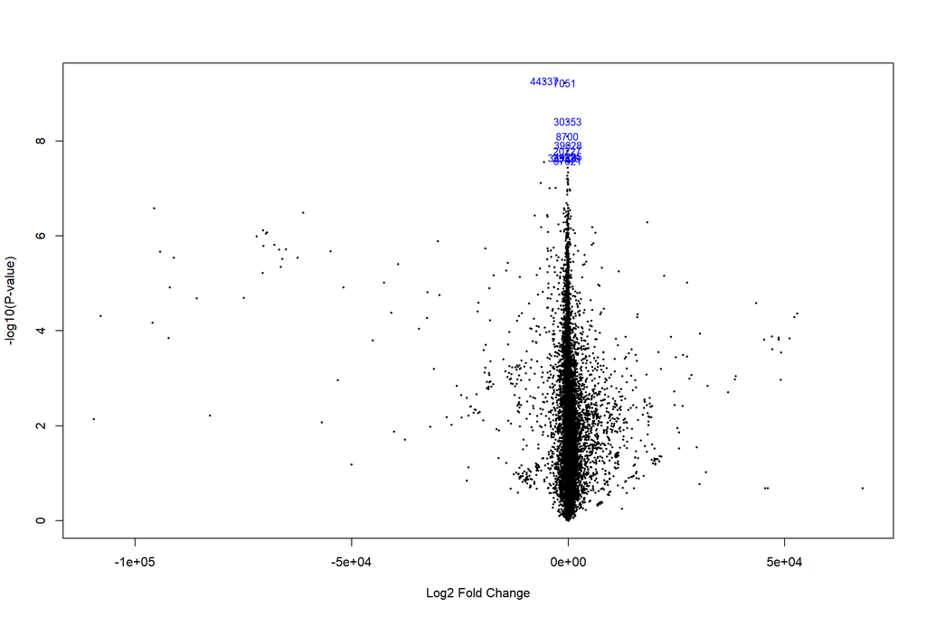

```r
volcanoplot(fit.main, coef="cnVSus", highlight=10)
```

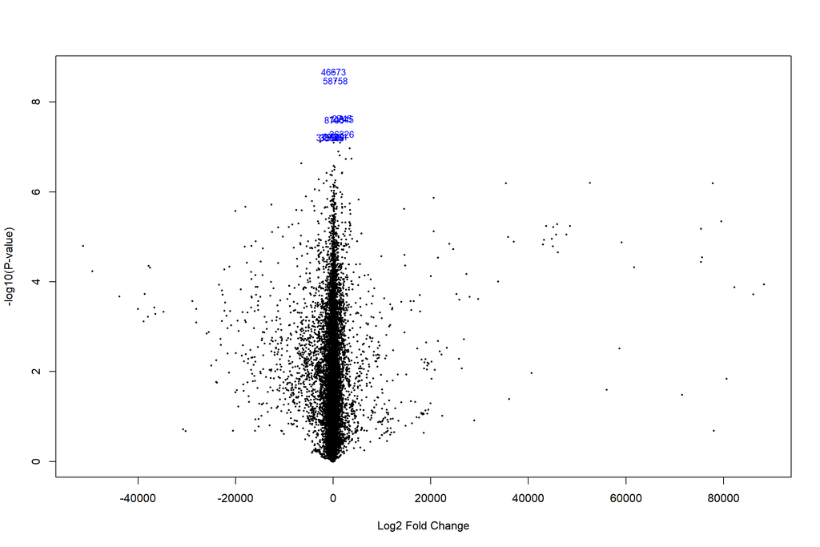

```r
volcanoplot(fit.main, coef="unVScs", highlight=10)
```

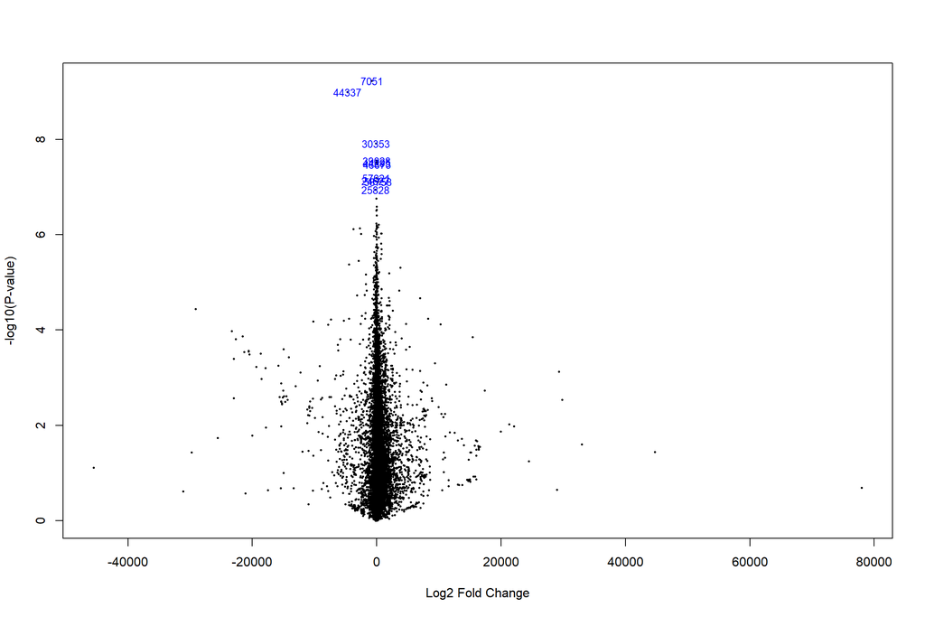

```r
volcanoplot(fit.main, coef="unVSus", highlight=10)
```

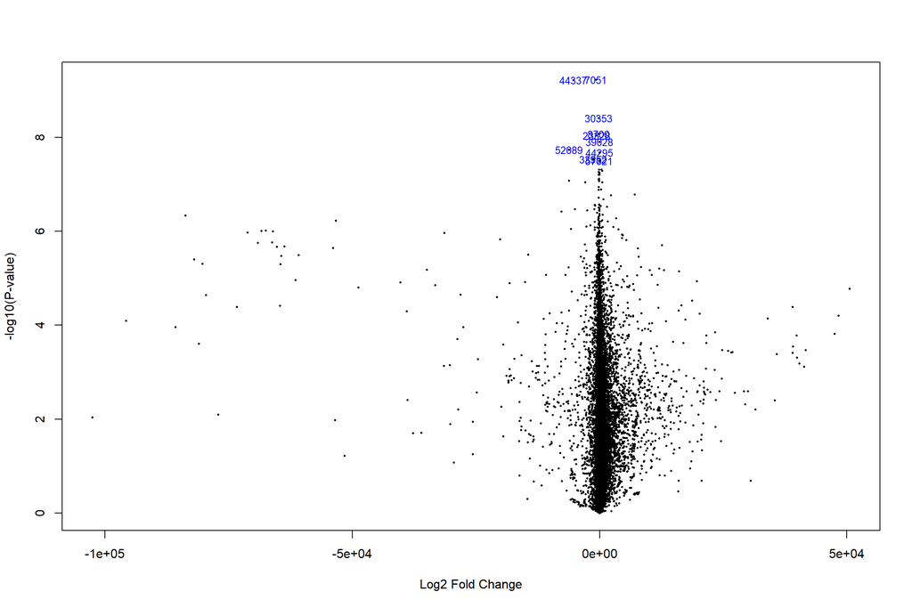

```r
volcanoplot(fit.main, coef="csVSus", highlight=10)
```